# Identifying the Most Dangerous and Costly Severe Weather Events in the U.S.

Author: Lowell Ricketts Date: February 2016

# Synopsis

I find that excessive heat, tornados, and flash floods have caused the greatest loss of life in the U.S. since January 1996. On average, each instance of excessive heat, rip currents, and general heat have an 80 percent chance of killing at least one person. Flooding across the U.S. caused the most monetary damage ($149.1 billion). Along the coasts, hurricanes/typhoons and storm surges/tides caused $87.1 billion and $47.8 billion worth of damage, respectively. Crop damage made up a small share of overall losses except for droughts where they constituted 93 percent of the total damage.

# Introduction

This project was undertaken during the Coursera Reproducible Research course offered in the Data Science specialization tract, taught by Johns Hopkins University.

Storms and other severe weather events can cause both public health and economic problems for communities and municipalities. Many severe events can result in fatalities, injuries, and property damage, and preventing such outcomes to the extent possible is a key concern.

This project involves exploring the U.S. National Oceanic and Atmospheric Administration’s (NOAA) storm database. This database tracks characteristics of major storms and weather events in the United States, including when and where they occur, as well as estimates of any fatalities, injuries, and property damage.

# Data

The data for this assignment come in the form of a comma-separated-value file compressed via the bzip2 algorithm to reduce its size. You can download the file from the course web site: * [Storm Data](https://d396qusza40orc.cloudfront.net/repdata%2Fdata%2FStormData.csv.bz2) There is also some documentation of the database available. Here you will find how some of the variables are constructed/defined. * National Weather Service [Storm Data Documentation](https://d396qusza40orc.cloudfront.net/repdata%2Fpeer2_doc%2Fpd01016005curr.pdf) * National Climatic Data Center Storm Events [FAQ](https://d396qusza40orc.cloudfront.net/repdata%2Fpeer2_doc%2FNCDC%20Storm%20Events-FAQ%20Page.pdf) The events in the database start in the year 1950 and end in November 2011. In the earlier years of the database there are generally fewer events recorded, most likely due to a lack of good records. More recent years should be considered more complete.

# Data Processing

Load the dplyr, reshape2, and ggplot2 packages.

```r
library(dplyr)
```

```r
library(reshape2)
library(ggplot2)
```

Download the data from the source if it’s not already present in the working directory.

```r
# Download data and read in as data frame
if (!file.exists("./repdata%2Fdata%2FStormData.csv.bz2")) {
        fileUrl <- "https://d396qusza40orc.cloudfront.net/repdata%2Fdata%2FStormData.csv.bz2"
        download.file(fileUrl, "repdata%2Fdata%2FStormData.csv.bz2")
}

stormdata <- read.csv(bzfile("./repdata%2Fdata%2FStormData.csv.bz2"))
```

Start the lengthy data cleaning, starting with trimming useless data from the date variables and reformatting them as date variables.

```r
# Begin data cleaning
colnames(stormdata) <- tolower(colnames(stormdata))

# Remove time element in the bgn_date and end_date variables since it contains
# no information, convert to Date format. bgn_time and end_time have multiple
# coding formats and yield little value for analysis.
split <- colsplit(stormdata$bgn_date, " ", c("bgn_date", "trash"))
stormdata$bgn_date <- as.Date(split$bgn_date, "%m/%d/%Y")

# 243,411 observations of end_date are blank and yield missing values.
split <- colsplit(stormdata$end_date, " ", c("end_date", "trash"))
stormdata$end_date <- as.Date(split$end_date, "%m/%d/%Y")
```

According to the National Oceanic and Atmospheric Administration, only data on tornados were collected from 1950 to 1954, from 1955 to 1992 data on tornados, and thunderstorm wind and hail were recorded, from 1996 to present 48 event types were recorded as defined in the NWS Directive 10-1605. For the purposes of finding which types of storms caused the most fatalities and injuries, as well as property damage, only data from 1996 to the present is used. [See for more information](https://www.ncdc.noaa.gov/stormevents/details.jsp?type=eventtype)

```r
stormdata <- filter(stormdata, bgn_date >= "1996-01-01") %>%

        # Filter only those rows where there is at least one fatality, one
        # injury, some property damage, or some crop damage.
        filter(fatalities > 0 | injuries > 0 | propdmg > 0 | cropdmg > 0) %>%

        # Put damage estimates in dollar amounts based on codes provided by NWSI 10-1605
        # August 17, 2007. Then, select the variables for analysis. Then, filter only
        # those rows where there is at least one fatality, one injury, some property
        # damage, or some crop damage.
        mutate(propdmg = ifelse(propdmgexp == "K", 1e3 * propdmg,
                                ifelse(propdmgexp == "M", 1e6 * propdmg,
                                       ifelse(propdmgexp == "B", 1e9 * propdmg,
                                              propdmg))),
               cropdmg = ifelse(cropdmgexp == "K", 1e3 * cropdmg,
                                ifelse(cropdmgexp == "M", 1e6 * cropdmg,
                                       ifelse(cropdmgexp == "B", 1e9 * cropdmg,
                                              cropdmg)))) %>%

        # Select variables for analysis
        select(c(bgn_date, end_date, fatalities, evtype, state, injuries,
                 propdmg, cropdmg, remarks)) %>%

        # Reformat evtype and remarks from factor to character.
        mutate(evtype = tolower(as.character(evtype)),
               remarks = as.character(remarks)) %>%

        # Arrange in proposed order of importance.
        arrange(desc(fatalities, injuries, propdmg, cropdmg))
```

Next I created an event category variable populated with the 48 categorical events listed in Figure 2.1.1 in [NWSI 10-1605 Aug. 17, 2007](https://d396qusza40orc.cloudfront.net/repdata%2Fpeer2_doc%2Fpd01016005curr.pdf) Accessed on 9/23/2015

```r
events <- c("astronomical low tide", "avalanche", "blizzard", "coastal flood",
            "cold/Wind chill", "debris flow", "dense fog", "dense smoke",
            "drought", "dust devil", "dust storm", "excessive heat",
            "extreme cold/wind chill", "flash flood", "flood", "freezing fog",
            "frost/freeze", "funnel cloud", "hail", "heat", "heavy rain",
            "heavy snow", "high surf", "high wind", "hurricane/typhoon",
            "ice storm", "lakeshore flood", "lake-effect snow", "lightning",
            "marine hail", "marine high wind", "marine strong wind",
            "marine thunderstorm wind", "rip current", "seiche", "sleet",
            "storm surge/tide", "strong wind", "thunderstorm wind", "tornado",
            "tropical depression", "tropical storm", "tsunami", "volcanic ash",
            "waterspout", "wildfire", "winter storm", "winter weather")
```

Next, the real nitty gritty part of the assignment began. There were numerous records which had event types coded as something not listed in the 48 NWSI event types. I proceded to use the table() function to identify what appeared to be event types that intuitively fell within one of the 48 categories. As I reduced the number of irregular event types I had to refer to NWSI documentation to identify the most similar event type as what was suggested by the remarks within the particularly irregular records. No records were dropped, all of them were recoded according to the following lengthy list of commands.

```r
# Recode evtype observations to standard codes after inspecting table(evtype)
# to identify which events were coded as something other than the 48 events
# listed by the NWSI. The latter changes required looking up the remarks for
# specific observations. In particular, the "other" observations consisted of
# mostly "dust devils" and crop flooding due to heavy rain.
stormdata$evtype[grep("small", stormdata$evtype)] = events[19]
stormdata$evtype[grep("wild", stormdata$evtype)] = events[46]
stormdata$evtype[grep("brush", stormdata$evtype)] = events[46]
stormdata$evtype[grep("hurricane", stormdata$evtype)] = events[25]
stormdata$evtype[grep("typhoon", stormdata$evtype)] = events[25]
stormdata$evtype[grep("squall", stormdata$evtype)] = events[28]
stormdata$evtype[grep("lake effect", stormdata$evtype)] = events[28]
stormdata$evtype[grep("torrential", stormdata$evtype)] = events[21]
stormdata$evtype[grep("unseasonal", stormdata$evtype)] = events[21]
stormdata$evtype[grep("urban", stormdata$evtype)] = events[15]
stormdata$evtype[grep("warm", stormdata$evtype)] = events[20]
stormdata$evtype[grep("freeze", stormdata$evtype)] = events[17]
stormdata$evtype[grep("surf", stormdata$evtype)] = events[23]
stormdata$evtype[grep("rip", stormdata$evtype)] = events[34]
stormdata$evtype[grep("marine tstm wind", stormdata$evtype)] = events[33]
stormdata$evtype[grep("mix", stormdata$evtype)] = events[48]
stormdata$evtype[grep("rain/snow", stormdata$evtype)] = events[48]
stormdata$evtype[grep("record heat", stormdata$evtype)] = events[12]
stormdata$evtype[grep("river", stormdata$evtype)] = events[15]
stormdata$evtype[grep("mud", stormdata$evtype)] = events[6]
stormdata$evtype[grep("gust", stormdata$evtype)] = events[24]
stormdata$evtype[grep("non", stormdata$evtype)] = events[24]
stormdata$evtype[grep("tstm wind", stormdata$evtype)] = events[39]
stormdata$evtype[grep("exposure", stormdata$evtype)] = events[13]
stormdata$evtype[grep("light ", stormdata$evtype)] = events[48]
stormdata$evtype[grep("unseason", stormdata$evtype)] = events[13]
stormdata$evtype[grep("surge", stormdata$evtype)] = events[37]
stormdata$evtype[grep("blowing dust", stormdata$evtype)] = events[11]
stormdata$evtype[grep("flash", stormdata$evtype)] = events[14]
stormdata$evtype[grep("extreme cold", stormdata$evtype)] = events[13]
stormdata$evtype[grep("erosion", stormdata$evtype)] = events[4]
stormdata$evtype[grep("slide", stormdata$evtype)] = events[6]
stormdata$evtype[grep("excessive snow", stormdata$evtype)] = events[22]
stormdata$evtype[grep("thunderstorm wind ", stormdata$evtype)] = events[39]
stormdata$evtype[grep("blowing", stormdata$evtype)] = events[3]
stormdata$evtype[grep("cold temperature", stormdata$evtype)] = events[5]
stormdata$evtype[grep("rain/snow", stormdata$evtype)] = events[48]
stormdata$evtype[grep("shower", stormdata$evtype)] = events[22]
stormdata$evtype[grep("extreme", stormdata$evtype)] = events[13]
stormdata$evtype[grep("road", stormdata$evtype)] = events[48]
stormdata$evtype[grep("coastal", stormdata$evtype)] = events[4]
stormdata$evtype[grep("cold", stormdata$evtype)] = events[5]
stormdata$evtype[grep("ice jam", stormdata$evtype)] = events[15]
stormdata$evtype[grep("glaze", stormdata$evtype)] = events[48]
stormdata$evtype[grep("black", stormdata$evtype)] = events[48]
stormdata$evtype[grep("freezing drizzle", stormdata$evtype)] = events[48]
stormdata$evtype[grep("falling", stormdata$evtype)] = events[48]
stormdata$evtype[grep("microburst", stormdata$evtype)] = events[38]
stormdata$evtype[grep("downburst", stormdata$evtype)] = events[38]
stormdata$evtype[grep("landslump", stormdata$evtype)] = events[6]
stormdata$evtype[grep("landspout", stormdata$evtype)] = events[40]
stormdata$evtype[grep("high water", stormdata$evtype)] = events[21]
stormdata$evtype[which(stormdata$evtype == "late season snow")] = events[48]
stormdata$evtype[which(stormdata$evtype == "fog")] = events[7]
stormdata$evtype[which(stormdata$evtype == "freezing rain")] = events[48]
stormdata$evtype[which(stormdata$evtype == "snow and ice")] = events[48]
stormdata$evtype[which(stormdata$evtype == "frost")] = events[17]
stormdata$evtype[which(stormdata$evtype == "heat wave")] = events[12]
stormdata$evtype[which(stormdata$evtype == "gradient wind")] = events[24]
stormdata$evtype[which(stormdata$evtype == "high wind (g40)")] = events[24]
stormdata$evtype[which(stormdata$evtype == "high winds")] = events[24]
stormdata$evtype[which(stormdata$evtype == "strong winds")] = events[38]
stormdata$evtype[which(stormdata$evtype == "freezing spray")] = events[38]
stormdata$evtype[which(stormdata$evtype == "wind damage")] = events[38]
stormdata$evtype[which(stormdata$evtype == "early frost")] = events[17]
stormdata$evtype[which(stormdata$evtype == "drowning")] = events[21]
stormdata$evtype[which(stormdata$evtype == "rain")] = events[21]
stormdata$evtype[which(stormdata$evtype == "winds")] = events[32]
stormdata$evtype[which(stormdata$evtype == "heavy seas")] = events[23]
stormdata$evtype[which(stormdata$evtype == "rough seas")] = events[23]
stormdata$evtype[which(stormdata$evtype == "rogue wave")] = events[23]
stormdata$evtype[which(stormdata$evtype == "high seas")] = events[23]
stormdata$evtype[which(stormdata$evtype == "marine accident")] = events[23]
stormdata$evtype[which(stormdata$evtype == "astronomical high tide")] = events[23]
stormdata$evtype[which(stormdata$evtype == "wind and wave")] = events[23]
stormdata$evtype[which(stormdata$evtype == "high swells")] = events[23]
stormdata$evtype[which(stormdata$evtype == "dam break")] = events[14]
stormdata$evtype[which(stormdata$evtype == "tidal flooding")] = events[15]
stormdata$evtype[which(stormdata$evtype == "wind")] = events[24]
stormdata$evtype[which(stormdata$evtype == "snow")] = events[22]
stormdata$evtype[2500] = events[48]
stormdata$evtype[19694] = events[39]
stormdata$evtype[1335] = events[10]
stormdata$evtype[9541] = events[10]
stormdata$evtype[19677] = events[10]
stormdata$evtype[70686] = events[32]
stormdata$evtype[20454:20483] = events[21]
stormdata$evtype[54842] = events[10]
stormdata$evtype[65845] = events[10]
stormdata$evtype[5481] = events[2]
```

The last piece of data processing involved creating binary variables which indicate wether an event had at least one fatality, or one injury, or property damage, or crop damage. These are used for a figure later on which details the lethal nature of the various event types.

```r
# Create binary bins for fatalities, injuries, property damage, and crop damage
stormdata <- mutate(stormdata, lethal = ifelse(fatalities > 0, 1, 0),
                    hurtful = ifelse(injuries > 0, 1, 0),
                    damaging = ifelse(propdmg > 0, 1, 0),
                    withering = ifelse(cropdmg > 0, 1, 0))
```

# Results

To begin analysis I created a summary data frame which had the total of fatalities, injuries, property damage, and crop damage over time for each of the event types. I also calculated the mean over time for each of the event types.

```r
# Begin analysis
storm_summary <- group_by(stormdata, evtype) %>%
        # Identify the sum of metrics over time as well as share of incidents as
        # provided by the binary indicators
        summarise(total_fatalities = sum(fatalities),
                  total_injuries = sum(injuries),
                  total_propdmg = sum(propdmg),
                  total_cropdmg = sum(cropdmg),
                  share_lethal = 100 * round(mean(lethal),2),
                  share_hurtful = 100 * round(mean(hurtful),2),
                  mean_propdmg = 100 * round(mean(propdmg),2),
                  mean_cropdmg = 100 * round(mean(cropdmg),2)) %>%

        arrange(desc(total_fatalities, total_injuries,
                     total_propdmg, total_cropdmg))
```

The first figure, shown below, compares the total number of fatalities since January 1996 for the 10 most lethal event types. Episodes of **excessive heat** combined for **1,799** deaths across the United States. **Tornado’s** were a close second with **1,511** deaths. The death toll **drops 41 percent** for **flash floods** which cost the lives of **887** people.

Fortunately, excessive heat is an event that carries with it substantial forewarning and offers a significant window wherein civic leaders can mobilize resources to help those who are the most vulnerable, such as the elderly, homeless, and outdoor laborers.

For more information see the [Ready.gov Resources on Extreme Heat.](http://www.ready.gov/heat)

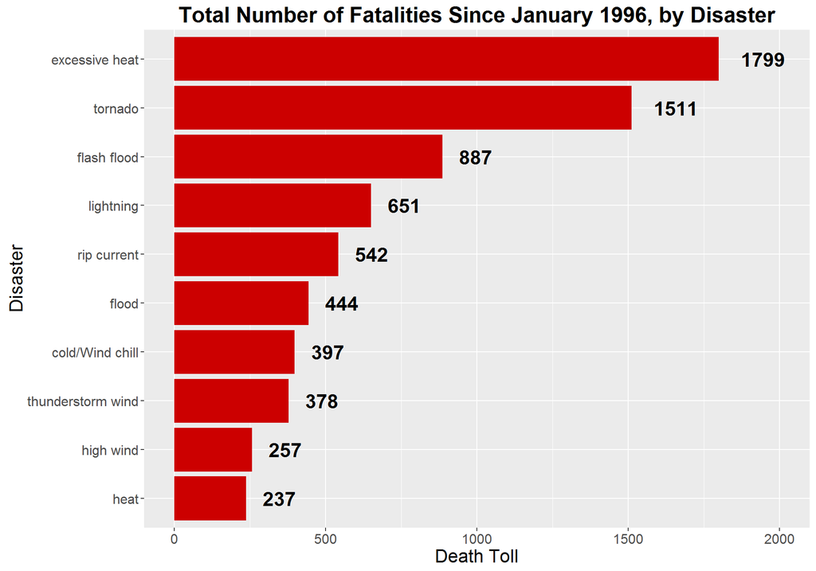

```r
# Create bar chart of total fatalities by event type, using ggplot2
graphset <- head(storm_summary, 10)
plot1 <- ggplot(graphset, aes(x = reorder(evtype, total_fatalities), y = total_fatalities)) +
        geom_bar(fill = "#CC0000", stat = "identity") +
        geom_text(aes(label = total_fatalities), size = 6, hjust = -.5, fontface = "bold") +
        labs(title = "Total Number of Fatalities Since January 1996, by Disaster") +
        coord_flip() +
        labs(x = expression("Disaster")) +
        labs(y = expression("Death Toll")) +
        theme(title = element_text(size = 16, face = "bold"),
              axis.text = element_text(size = 12),
              axis.title = element_text(size = 16, face = "bold")) +
        scale_y_continuous(limits = c(0,2000))
print(plot1)
```

For the next figure I looked at the share of total event incidents which resulted in at least one fatality. Loss of life is arguably the greatest loss and identifying which events are more likely to result in fatalities, even for the smaller events, is worth identifying.

Once again **excessive heat** is the most lethal of the events, with **82 percent** of instances resulting in at least one fatality. Interestingly, **rip currents** are also highly lethal events with **80 percent** of occurance resulting in death. Excessive heat’s close cousin **heat** kills **78 percent** of the time, rounding out the top 3.

Civic leaders in coastal areas should take note of these results. Rip current’s are a common occurance with [tens of thousands](http://oceanservice.noaa.gov/facts/ripcurrent.html) of people rescued from rip currents in the US every year. There are numerous safety lessons which can help avoid fatalities in the event of a rip current: * If caught in a rip current **DON’T PANIC** * Only swim at beaches with lifeguards present * Check water conditions before going to the beach by looking at the local beach forecast

For more information on rip current safety, including how to spot them, see this National Weather Service [resource](http://www.ripcurrents.noaa.gov/).

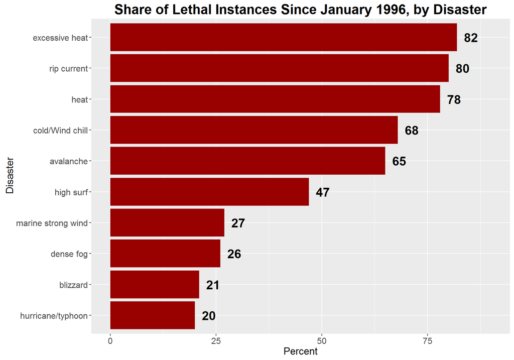

```r
graphset <- head(arrange(storm_summary, desc(share_lethal, share_hurtful)), 10)

# Create bar chart which shows how certain disastors are more likely to cause
# at least some loss of life
plot3 <- ggplot(graphset, aes(x = reorder(evtype, share_lethal), y = share_lethal)) +
        geom_bar(fill = "#990000", stat = "identity") +
        geom_text(aes(label = share_lethal), size = 6, fontface = "bold", hjust = -.5) +
        labs(title = "Share of Lethal Instances Since January 1996, by Disaster") +
        coord_flip() +
        labs(x = expression("Disaster")) +
        labs(y = expression("Percent")) +
        theme(title = element_text(size = 16, face = "bold"),
              axis.text = element_text(size = 12),
              axis.title = element_text(size = 14, face = "bold")) +
        scale_y_continuous(limits = c(0,90))
print(plot3)
```

Lastly, I wanted to look at the ranking of event types by the total monetary damage that they have caused since January 1996. Monetary damage is the sum of property damage as well as damage to agricultural crops. Unlike the rankings for fatalities the three most damaging event types were: **floods**, **hurricane and typhoons**, and **storm surges/tides**. Flooding has cost the United States **$149.1 billion**. That number is unadjusted for inflation so the real impact would likely be much higher. Hurricanes and typhoons combined for **$87.1 billion** worth of damage, and storm surges and tides destroyed **$47.8 billion** worth of property. To minimize the economic cost of flooding, urban planners and developers should avoid developing flood plains. Interestingly, crop damage comprised a very small share of most event types economic impact. Although it constituted close to **93 percent** of damage done by droughts.

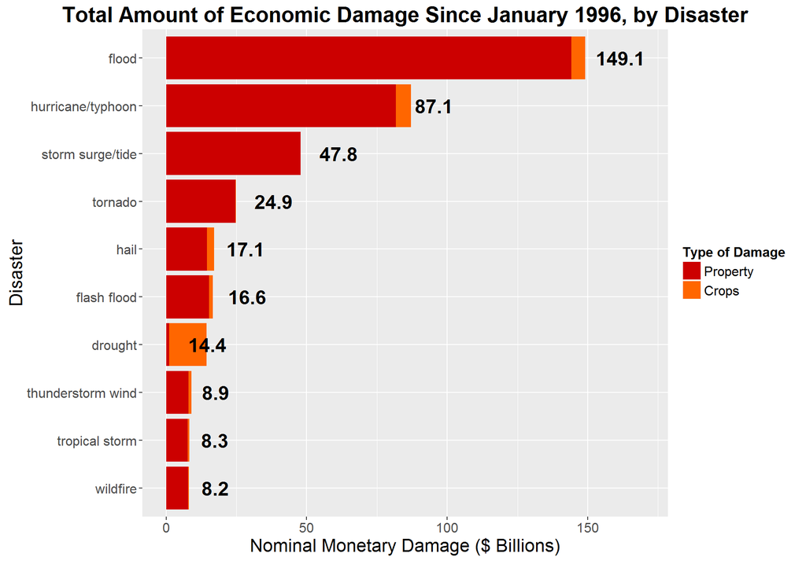

```r
graphset <- head(arrange(storm_summary, desc(total_propdmg + total_cropdmg)), 10)

dat <- select(graphset, c(evtype, total_propdmg, total_cropdmg))

graphset$total = rowSums(graphset[,4:5])

# Calculate the share of overall drought damage consisting of damage to crops
droughtcropdmg <- 100 * graphset$total_cropdmg[7] / graphset$total[7]

graphset <-  select(graphset, c(total)) %>%
        arrange(desc(total))

dat <- melt(dat, id = "evtype")
dat <- cbind(dat, rep(graphset,1))
dat[11:20,4] = NA

# Create a bar chart which shows the total amount of monetary damage caused by
# the top 10 worst disasters (in terms of total monetary damage). Stack charts
# to show contribution of crop damage to the total.
plot5 <- ggplot(dat, aes(x = reorder(evtype, value), y = value/1000000000, fill = variable)) +
        geom_bar(stat = "identity") +
        geom_text(aes(label = round((total/1000000000),1)),
                  size = 6, hjust = -.5, fontface = "bold") +
        labs(title = "Total Amount of Economic Damage Since January 1996, by Disaster") +
        coord_flip() +
        labs(x = expression("Disaster")) +
        labs(y = expression("Nominal Monetary Damage ($ Billions)")) +
        scale_fill_manual(values= c("#CC0000", "#FF6600"),
                          name="Type of Damage",
                            breaks=c("total_propdmg", "total_cropdmg"),
                            labels=c("Property", "Crops")) +
        theme(title = element_text(size = 16, face = "bold"),
              axis.text = element_text(size = 12),
              axis.title = element_text(size = 16, face = "bold"),
              legend.title = element_text(size = 12, face = "bold"),
              legend.text = element_text(size = 12)) +
        scale_color_discrete(name = "Type of Damage") +
        scale_y_continuous(limits = c(0,170))
suppressWarnings(print(plot5))
```

```r
droughtcropdmg
```

```
## [1] 92.7423
```

# Conclusion

In summary, much of the death toll caused by severe weather events can be prevented with better support provided to vulnerable communities. Much of the economic impact of these disasters could be avoided with adifferent development pattern that avoids flood plains as well as coastal areas.